# Loan Data Exploration

## Preliminary Wrangling

This document explores a dataset containing 113,937 loans with 81 variables on each loan, including loan amount, borrower rate (or interest rate), current loan status, borrower income, and many others.

```python
# import all packages and set plots to be embedded inline
import numpy as np
import pandas as pd
import matplotlib.pyplot as plt
import seaborn as sb

%matplotlib inline
```

> Load in your dataset and describe its properties through the questions below. Try and motivate your exploration goals through this section.

```python
#load in dataset into a pandas dataframe
loan = pd.read_csv('prosperLoanData.csv')
```

```python
#high level overview of data shape and composition
print(loan.shape)
print(loan.dtypes)
print(loan.info)
```

```
(113937, 81)
ListingKey                      object
ListingNumber                    int64
ListingCreationDate             object
CreditGrade                     object
Term                             int64
                                ...
PercentFunded                  float64
Recommendations                  int64
InvestmentFromFriendsCount       int64
InvestmentFromFriendsAmount    float64
Investors                        int64
Length: 81, dtype: object
<bound method DataFrame.info of                      ListingKey  ListingNumber            ListingCreationDate  \
0       1021339766868145413AB3B         193129  2007-08-26 19:09:29.263000000
1       10273602499503308B223C1        1209647  2014-02-27 08:28:07.900000000
2       0EE9337825851032864889A          81716  2007-01-05 15:00:47.090000000
3       0EF5356002482715299901A         658116  2012-10-22 11:02:35.010000000
4       0F023589499656230C5E3E2         909464  2013-09-14 18:38:39.097000000
...                         ...            ...                            ...
113932  E6D9357655724827169606C         753087  2013-04-14 05:55:02.663000000
113933  E6DB353036033497292EE43         537216  2011-11-03 20:42:55.333000000
113934  E6E13596170052029692BB1        1069178  2013-12-13 05:49:12.703000000
113935  E6EB3531504622671970D9E         539056  2011-11-14 13:18:26.597000000
113936  E6ED3600409833199F711B7        1140093  2014-01-15 09:27:37.657000000

       CreditGrade  Term              LoanStatus           ClosedDate  \
0                C    36               Completed  2009-08-14 00:00:00
1              NaN    36                 Current                  NaN
2               HR    36               Completed  2009-12-17 00:00:00
3              NaN    36                 Current                  NaN
4              NaN    36                 Current                  NaN
...            ...   ...                     ...                  ...
113932         NaN    36                 Current                  NaN
113933         NaN    36  FinalPaymentInProgress                  NaN
113934         NaN    60                 Current                  NaN
113935         NaN    60               Completed  2013-08-13 00:00:00
113936         NaN    36                 Current                  NaN

        BorrowerAPR  BorrowerRate  LenderYield  ...  LP_ServiceFees  \
```

[output cut: 37 more lines]

```

       InvestmentFromFriendsCount InvestmentFromFriendsAmount Investors
0                               0                         0.0       258
1                               0                         0.0         1
2                               0                         0.0        41
3                               0                         0.0       158
4                               0                         0.0        20
...                           ...                         ...       ...
113932                          0                         0.0         1
113933                          0                         0.0        22
113934                          0                         0.0       119
113935                          0                         0.0       274
113936                          0                         0.0         1

[113937 rows x 81 columns]>
```

```python
loan.head()
```

|  | ListingKey | ListingNumber | ListingCreationDate | CreditGrade | Term | LoanStatus | ClosedDate | BorrowerAPR | BorrowerRate | LenderYield | ... | LP_ServiceFees | LP_CollectionFees | LP_GrossPrincipalLoss | LP_NetPrincipalLoss | LP_NonPrincipalRecoverypayments | PercentFunded | Recommendations | InvestmentFromFriendsCount | InvestmentFromFriendsAmount | Investors |
| --- | --- | --- | --- | --- | --- | --- | --- | --- | --- | --- | --- | --- | --- | --- | --- | --- | --- | --- | --- | --- | --- |
| 0 | 1021339766868145413AB3B | 193129 | 2007-08-26 19:09:29.263000000 | C | 36 | Completed | 2009-08-14 00:00:00 | 0.16516 | 0.1580 | 0.1380 | ... | -133.18 | 0.0 | 0.0 | 0.0 | 0.0 | 1.0 | 0 | 0 | 0.0 | 258 |
| 1 | 10273602499503308B223C1 | 1209647 | 2014-02-27 08:28:07.900000000 | NaN | 36 | Current | NaN | 0.12016 | 0.0920 | 0.0820 | ... | 0.00 | 0.0 | 0.0 | 0.0 | 0.0 | 1.0 | 0 | 0 | 0.0 | 1 |
| 2 | 0EE9337825851032864889A | 81716 | 2007-01-05 15:00:47.090000000 | HR | 36 | Completed | 2009-12-17 00:00:00 | 0.28269 | 0.2750 | 0.2400 | ... | -24.20 | 0.0 | 0.0 | 0.0 | 0.0 | 1.0 | 0 | 0 | 0.0 | 41 |
| 3 | 0EF5356002482715299901A | 658116 | 2012-10-22 11:02:35.010000000 | NaN | 36 | Current | NaN | 0.12528 | 0.0974 | 0.0874 | ... | -108.01 | 0.0 | 0.0 | 0.0 | 0.0 | 1.0 | 0 | 0 | 0.0 | 158 |
| 4 | 0F023589499656230C5E3E2 | 909464 | 2013-09-14 18:38:39.097000000 | NaN | 36 | Current | NaN | 0.24614 | 0.2085 | 0.1985 | ... | -60.27 | 0.0 | 0.0 | 0.0 | 0.0 | 1.0 | 0 | 0 | 0.0 | 20 |

5 rows × 81 columns

```python
print(loan.describe())
```

```
       ListingNumber           Term    BorrowerAPR   BorrowerRate  \
count   1.139370e+05  113937.000000  113912.000000  113937.000000
mean    6.278857e+05      40.830248       0.218828       0.192764
std     3.280762e+05      10.436212       0.080364       0.074818
min     4.000000e+00      12.000000       0.006530       0.000000
25%     4.009190e+05      36.000000       0.156290       0.134000
50%     6.005540e+05      36.000000       0.209760       0.184000
75%     8.926340e+05      36.000000       0.283810       0.250000
max     1.255725e+06      60.000000       0.512290       0.497500

         LenderYield  EstimatedEffectiveYield  EstimatedLoss  EstimatedReturn  \
count  113937.000000             84853.000000   84853.000000     84853.000000
mean        0.182701                 0.168661       0.080306         0.096068
std         0.074516                 0.068467       0.046764         0.030403
min        -0.010000                -0.182700       0.004900        -0.182700
25%         0.124200                 0.115670       0.042400         0.074080
50%         0.173000                 0.161500       0.072400         0.091700
75%         0.240000                 0.224300       0.112000         0.116600
max         0.492500                 0.319900       0.366000         0.283700

       ProsperRating (numeric)  ProsperScore  ...  LP_ServiceFees  \
count             84853.000000  84853.000000  ...   113937.000000
mean                  4.072243      5.950067  ...      -54.725641
std                   1.673227      2.376501  ...       60.675425
min                   1.000000      1.000000  ...     -664.870000
25%                   3.000000      4.000000  ...      -73.180000
50%                   4.000000      6.000000  ...      -34.440000
75%                   5.000000      8.000000  ...      -13.920000
max                   7.000000     11.000000  ...       32.060000

       LP_CollectionFees  LP_GrossPrincipalLoss  LP_NetPrincipalLoss  \
count      113937.000000          113937.000000        113937.000000
mean          -14.242698             700.446342           681.420499
std           109.232758            2388.513831          2357.167068
min         -9274.750000             -94.200000          -954.550000
25%             0.000000               0.000000             0.000000
50%             0.000000               0.000000             0.000000
75%             0.000000               0.000000             0.000000
max             0.000000           25000.000000         25000.000000

       LP_NonPrincipalRecoverypayments  PercentFunded  Recommendations  \
count                    113937.000000  113937.000000    113937.000000
mean                         25.142686       0.998584         0.048027
std                         275.657937       0.017919         0.332353
min                           0.000000       0.700000         0.000000
25%                           0.000000       1.000000         0.000000
50%                           0.000000       1.000000         0.000000
75%                           0.000000       1.000000         0.000000
max                       21117.900000       1.012500        39.000000

       InvestmentFromFriendsCount  InvestmentFromFriendsAmount      Investors
count               113937.000000                113937.000000  113937.000000
mean                     0.023460                    16.550751      80.475228
std                      0.232412                   294.545422     103.239020
min                      0.000000                     0.000000       1.000000
25%                      0.000000                     0.000000       2.000000
50%                      0.000000                     0.000000      44.000000
75%                      0.000000                     0.000000     115.000000
max                     33.000000                 25000.000000    1189.000000

[8 rows x 61 columns]
```

### What is the structure of your dataset?

> There are 113,937 loans in the dataset with 81 variables on each loan, including loan amount, borrower rate (or interest rate), current loan status, borrower income, credit scores, and many others.

### What is/are the main feature(s) of interest in your dataset?

> I'm interested in figuring out what factors affect a loan's outcome status, and the borrower's APR or interest rate?

### What features in the dataset do you think will help support your investigation into your feature(s) of interest?

> I expect that several factors will have a negative effect on the loan interest rate, such as a loaner's credit score and debt to income ratio. Some factors such as loan amount and delinquencies will also have effects on the loan interest rate.

## Univariate Exploration

> I'll start by looking at the distribution of the main variable of interest: Borrower APR.

```python
loan.BorrowerAPR.describe()
```

```
count    113912.000000
mean          0.218828
std           0.080364
min           0.006530
25%           0.156290
50%           0.209760
75%           0.283810
max           0.512290
Name: BorrowerAPR, dtype: float64
```

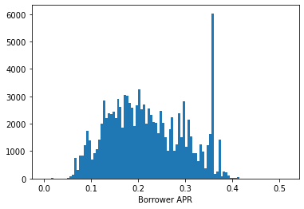

```python
#plotting Borrower's APR on a standard scale
binsize=0.005
bins = np.arange(0, loan.BorrowerAPR.max()+binsize, binsize)
plt.hist(data=loan, x='BorrowerAPR', bins=bins)
plt.xlabel('Borrower APR');
```

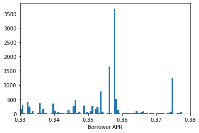

```python
#investigating further on an even smaller bin size noticing the spike between 0.33 to 0.38
binsize=0.0005
bins = np.arange(0.33, 0.38, binsize)
plt.hist(data=loan, x='BorrowerAPR', bins=bins)
plt.xlim([0.33, 0.38])
plt.xlabel('Borrower APR');
```

> In the case of borrower's APR, the small bin size proves that there are very large spikes in frequency at the bars around 0.358. This rate takes almost 5% of the APR in the dataset. Besides the large spike around 0.35 to 0.36, the borrower' APR is roughly normally distributed.

> Next, we will take a look at borrower's interest rate, credit score, prosper's rating, debt to income ratio, income range, loan orignal amount.

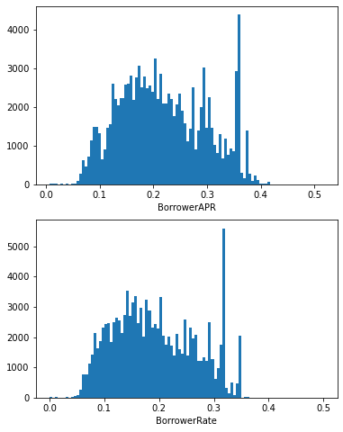

```python
#Borrower's Interest Rate
#since borrower's interest rate is part of borrower's APR, we will plot these two variables together to get an idea of each variable's distribution
fig, ax = plt.subplots(nrows=2, figsize=[6,8])

variables = ['BorrowerAPR', 'BorrowerRate']
for i in np.arange(len(variables)):
    var = variables[i]
    bins = np.arange(min(loan[var]), max(loan[var])+0.005, 0.005)
    ax[i].hist(data=loan, x=var, bins=bins)
    ax[i].set_xlabel('{}'.format(var))
plt.show()
```

> The plot of borrower's interest rate show some immediate points of attention. Interestingly, the interest rate also has a spike around 0.32 to 0.34 and is roughly normally distributed excluding the spike. As we can see, the rate lags a little bit for the APR. Interest rate is part of APR. And on top of the interest rate, there are some other expenses associated with the loan. It makes sense that APR lags a little behind than the interest rate. To some extent, it also reflects that interest rate is one of the main factors that impact APR.

> I'll now move on to proper's ratings.

```python
loan['ProsperRating (numeric)'].unique()
```

```
array([nan,  6.,  3.,  5.,  2.,  4.,  7.,  1.])
```

```python
loan.LoanStatus.unique()
```

```
array(['Completed', 'Current', 'Past Due (1-15 days)', 'Defaulted',
       'Chargedoff', 'Past Due (16-30 days)', 'Cancelled',
       'Past Due (61-90 days)', 'Past Due (31-60 days)',
       'Past Due (91-120 days)', 'FinalPaymentInProgress',
       'Past Due (>120 days)'], dtype=object)
```

```python
ordinal_var_dict = {'ProsperRating (Alpha)': ['AA', 'A', 'B', 'C', 'D', 'E', 'HR'],
                   'ProsperRating (numeric)': [1, 2, 3, 4, 5, 6, 7],
                   'ProsperScore': [1, 2, 3, 4, 5, 6, 7, 8, 9, 10],
                    'Term' : [12, 36, 60],
                   'IncomeRange': ['$1-24,999', '$25,000-49,999', '$50,000-74,999', '$75,000-99,999', '$100,000+'],
                   'LoanStatus': ['Completed', 'FinalPaymentInProgress', 'Current', 'Past Due (1-15 days)', 'Past Due (16-30 days)', 'Past Due (31-60 days)',
                                 'Past Due (61-90 days)', 'Past Due (91-120 days)', 'Past Due (>120 days)', 'Cancelled',
                                 'Chargedoff', 'Defaulted']}

for var in ordinal_var_dict:
    ordered_var = pd.api.types.CategoricalDtype(ordered=True,
                                               categories = ordinal_var_dict[var])
    loan[var] = loan[var].astype(ordered_var)
```

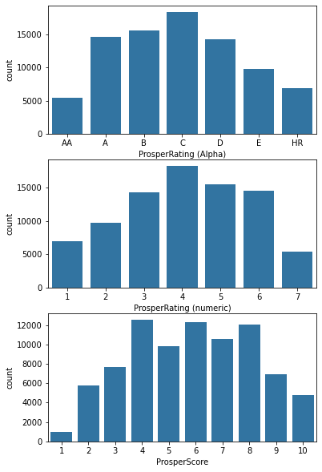

```python
#let's plot the 3 proper's ratings together
fig, ax = plt.subplots(nrows=3, figsize=[6,10])
proper_ratings = ['ProsperRating (Alpha)', 'ProsperRating (numeric)', 'ProsperScore']
default_color = sb.color_palette()[0]
sb.countplot(data=loan, x='ProsperRating (Alpha)', color=default_color, ax=ax[0])
sb.countplot(data=loan, x='ProsperRating (numeric)', color=default_color, ax=ax[1])
sb.countplot(data=loan, x='ProsperScore', color=default_color, ax=ax[2]);
```

> The credit rating between prosper's rating numeric vs alpha is pretty consistent, with most of the borrowers under C for prosper rating alpha, and 4 for prosper rating numeric. Most borrowers are within prosper scores 4-7. It makes sense as prosper rating is the system prosper has developed to calculate the credit worthiness of customers. It takes into account similar factors.

> We will look into borrower's credit score range and see if we can find anything.

```python
#notice there are credit score upper range at 19. Noticing most of the data are missing for these borrowers, I decided to drop these rows.
loan.loc[loan['CreditScoreRangeUpper']==19]
```

|  | ListingKey | ListingNumber | ListingCreationDate | CreditGrade | Term | LoanStatus | ClosedDate | BorrowerAPR | BorrowerRate | LenderYield | ... | LP_ServiceFees | LP_CollectionFees | LP_GrossPrincipalLoss | LP_NetPrincipalLoss | LP_NonPrincipalRecoverypayments | PercentFunded | Recommendations | InvestmentFromFriendsCount | InvestmentFromFriendsAmount | Investors |
| --- | --- | --- | --- | --- | --- | --- | --- | --- | --- | --- | --- | --- | --- | --- | --- | --- | --- | --- | --- | --- | --- |
| 794 | 00EF338150577356881AD6B | 97950 | 2007-02-11 13:40:55.490000000 | NC | 36 | Completed | 2010-02-22 00:00:00 | 0.29776 | 0.2900 | 0.2850 | ... | -34.97 | 0.0000 | 0.00 | 0.00 | 0.00 | 1.0 | 0 | 0 | 0.0 | 38 |
| 912 | 7A41337257909407897EB67 | 61512 | 2006-11-14 08:23:08.430000000 | NC | 36 | Defaulted | 2007-11-18 00:00:00 | 0.27276 | 0.2600 | 0.2450 | ... | -4.10 | 0.0000 | 1290.20 | 1290.21 | 0.00 | 1.0 | 0 | 0 | 0.0 | 11 |
| 1685 | 403F33816853903261A0142 | 94290 | 2007-02-06 15:50:46.723000000 | NC | 36 | Chargedoff | 2008-04-20 00:00:00 | 0.18065 | 0.1625 | 0.1575 | ... | -1.11 | -19.1100 | 846.17 | 846.19 | 0.00 | 1.0 | 0 | 0 | 0.0 | 64 |
| 4290 | 4B4C33658186085093BB6B4 | 7055 | 2006-04-23 14:19:41.030000000 | NC | 36 | Chargedoff | 2007-12-25 00:00:00 | 0.24502 | 0.2375 | 0.2325 | ... | -21.31 | 0.0000 | 2671.35 | 2671.35 | 0.00 | 1.0 | 0 | 0 | 0.0 | 24 |
| 4371 | 985433663733409747DA533 | 31236 | 2006-08-14 11:45:59.710000000 | NC | 36 | Defaulted | 2007-09-26 00:00:00 | 0.24505 | 0.2325 | 0.2150 | ... | -4.67 | 0.0000 | 1261.08 | 1261.07 | 0.00 | 1.0 | 0 | 0 | 0.0 | 50 |
| ... | ... | ... | ... | ... | ... | ... | ... | ... | ... | ... | ... | ... | ... | ... | ... | ... | ... | ... | ... | ... | ... |
| 109522 | 2575337371414583913B6EA | 60886 | 2006-11-13 06:36:16.067000000 | NC | 36 | Chargedoff | 2008-01-29 00:00:00 | 0.21543 | 0.2000 | 0.1950 | ... | -3.80 | -22.2039 | 995.44 | 875.42 | 259.99 | 1.0 | 0 | 0 | 0.0 | 4 |
| 109855 | FE063379142663462D83FD4 | 85920 | 2007-01-17 13:07:35.540000000 | NC | 36 | Completed | 2010-02-08 00:00:00 | 0.22643 | 0.2190 | 0.1840 | ... | -25.01 | -39.8900 | 0.00 | 0.00 | 0.00 | 1.0 | 0 | 0 | 0.0 | 30 |
| 110290 | 7AB333803121117292D39C0 | 97521 | 2007-02-10 21:22:12.553000000 | NC | 36 | Chargedoff | 2009-08-22 00:00:00 | 0.17752 | 0.1594 | 0.1244 | ... | -7.41 | 0.0000 | 381.29 | 381.30 | 0.00 | 1.0 | 0 | 0 | 0.0 | 20 |
| 111624 | B4F6337744905877323E37A | 82404 | 2007-01-07 20:33:39.027000000 | NC | 36 | Defaulted | 2007-07-22 00:00:00 | 0.29776 | 0.2900 | 0.2550 | ... | 0.00 | 0.0000 | 3002.00 | 2921.95 | 0.00 | 1.0 | 0 | 0 | 0.0 | 27 |
| 113848 | FFF0338012502972731B2C1 | 94872 | 2007-02-07 15:04:40.563000000 | NC | 36 | Completed | 2010-02-13 00:00:00 | 0.30709 | 0.2875 | 0.2825 | ... | -8.75 | -16.7100 | 0.00 | 0.00 | 0.00 | 1.0 | 0 | 0 | 0.0 | 12 |

133 rows × 81 columns

```python
#remove the data of the borrowers whose credit score upper range is 19
incorrect = loan['CreditScoreRangeUpper']==19
loan = loan.loc[-incorrect,:]
```

```python
loan.CreditScoreRangeLower.describe()
```

```
count    113213.000000
mean        686.373120
std          62.201999
min         360.000000
25%         660.000000
50%         680.000000
75%         720.000000
max         880.000000
Name: CreditScoreRangeLower, dtype: float64
```

```python
loan.CreditScoreRangeUpper.describe()
```

```
count    113213.000000
mean        705.373120
std          62.201999
min         379.000000
25%         679.000000
50%         699.000000
75%         739.000000
max         899.000000
Name: CreditScoreRangeUpper, dtype: float64
```

```python
loan['CreditScoreRangeLower'].min()
```

```
360.0
```

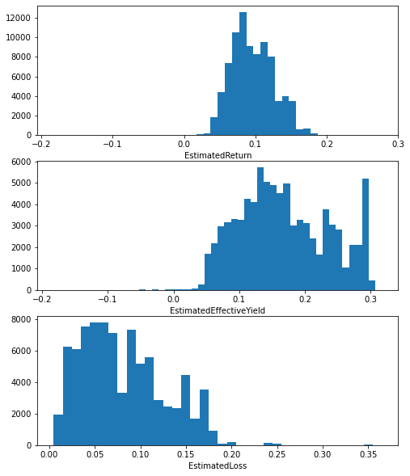

```python
fig, ax = plt.subplots(nrows=3, figsize=[8,10])

variables=['EstimatedReturn','EstimatedEffectiveYield', 'EstimatedLoss']
for i in np.arange(len(variables)):
    var = variables[i]
    bins = np.arange(loan[var].min(), loan[var].max(), 0.01)
    ax[i].hist(data=loan, x=var, bins=bins)
    ax[i].set_xlabel('{}'.format(var))
```

> Estimated return is the difference between the Estimated Effective Yield and the Estimated Loss Rate. The shapes of estimatede return proves the definition, and it's normally distributed.

> We will look into debt to income ratio.

```python
#notice that debt to income ratio fits in the log scale x axis.
loan.DebtToIncomeRatio.describe()
```

```
count    105311.000000
mean          0.276075
std           0.551883
min           0.000000
25%           0.140000
50%           0.220000
75%           0.320000
max          10.010000
Name: DebtToIncomeRatio, dtype: float64
```

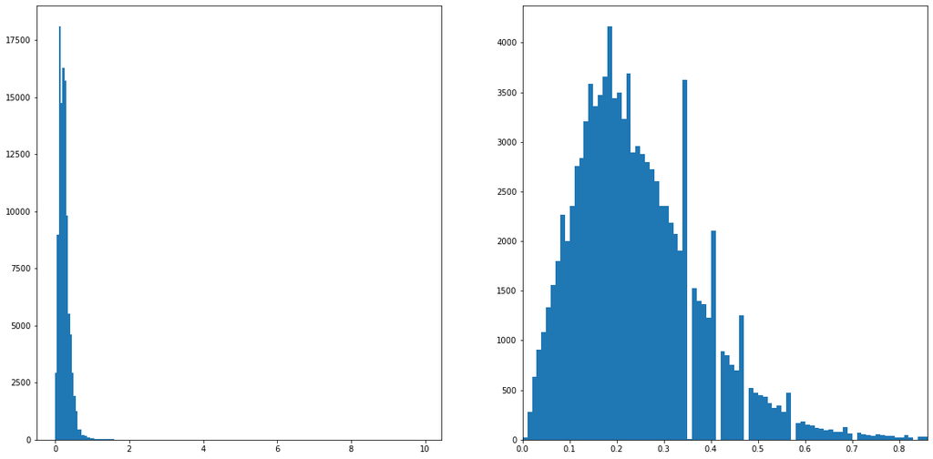

```python
plt.figure(figsize=[20,10])
#plot the debt to income ratio
plt.subplot(1,2,1)
bins=np.arange(0,10,0.05)
plt.hist(data=loan, x='DebtToIncomeRatio', bins=bins);

#plot the 99% debt to income ratio
plt.subplot(1,2,2)
bins=np.arange(0,1,0.01)
plt.hist(data=loan, x='DebtToIncomeRatio', bins=bins)
plt.xlim(0,loan.DebtToIncomeRatio.quantile(0.99));
```

```python
#drop the outliers based on the debt to income ratio
most_dtir = loan.DebtToIncomeRatio<=loan.DebtToIncomeRatio.quantile(0.99)
loan = loan.loc[most_dtir]
```

> Debt to income ratio is capped at 10.01 (any debt to income ratio larger than 1000% will be returned as 1001%). From above histograms, we can see that most of the borrower's debt to income ratio is below 1. So we include another visualization where a limit is set on the values included using 99th percentile.

> Before closing this section, we will take a look at the last two variables income range and loan status.

```python
type_count = loan.IncomeRange.value_counts().sort_index()
type_count
```

```
$1-24,999          5692
$25,000-49,999    29734
$50,000-74,999    29338
$75,000-99,999    16011
$100,000+         16065
Name: IncomeRange, dtype: int64
```

```python
total = loan.IncomeRange.value_counts().sum()
```

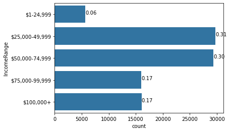

```python
base_color = sb.color_palette()[0]
sb.countplot(data=loan, y='IncomeRange', color=base_color);

for i in np.arange(len(type_count)):
    name = '{:0.2f}'.format(type_count[i]/total)
    plt.text(type_count[i]+10, i, s=name)
```

```python
loan['StatedMonthlyIncome'].describe()
```

```
count    104265.000000
mean       5697.896257
std        4942.943592
min           0.000000
25%        3333.333333
50%        4796.750000
75%        6916.666667
max      483333.333333
Name: StatedMonthlyIncome, dtype: float64
```

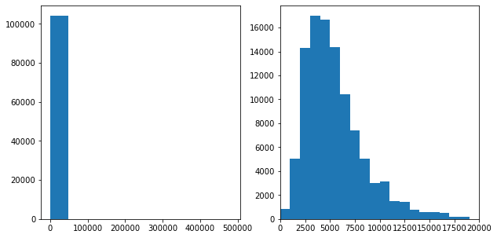

```python
plt.figure(figsize=[10,5])
#plot monthly income
plt.subplot(1,2,1)
plt.hist(data=loan, x='StatedMonthlyIncome');

#plot the 99% monthly income
plt.subplot(1,2,2)
bins=np.arange(0,20000,1000)
plt.hist(data=loan, x='StatedMonthlyIncome', bins=bins)
plt.xlim(0,loan.StatedMonthlyIncome.quantile(0.99));
```

> From the bar chart above, we can tell that most of the borrower's income is sitting in the range of 25,000 to 49,999, and 50,000 to 74,999. Most of borrowers' monthly income is between 2500 to 7500.

> Next, we will take a look at the loan status and loan amount.

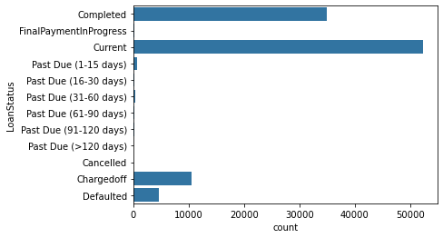

```python
#plot a bar chart for loan status
base_color = sb.color_palette()[0]
sb.countplot(data=loan, y='LoanStatus', color=base_color);
```

> As we can see, most of the loan status is under current, which means still in progress. The second biggest chunk of the borrower's status is completed, with only a few charged-off and defaulted loans.

```python
#remove the loan which principal is 0
invalid_loan=loan['ProsperPrincipalBorrowed']==0
loan=loan.loc[-invalid_loan]
```

```python
def log_trans(x, inverse=False):
    if not inverse:
        return np.log10(x)
    else:
        return np.power(10,x)
loan['log_monthly_income'] = loan['StatedMonthlyIncome'].apply(lambda x:log_trans(x))
```

```python
loan['log_principal'] = loan['ProsperPrincipalBorrowed'].apply(lambda x:log_trans(x))
```

```python
loan['log_principal'].describe()
```

```
count    19728.000000
mean         3.786228
std          0.361708
min          3.000000
25%          3.544068
50%          3.778151
75%          4.041586
max          4.826075
Name: log_principal, dtype: float64
```

```python
loan['ProsperPrincipalBorrowed'].describe()
```

```
count    19728.000000
mean      8515.522224
std       7388.174542
min       1000.000000
25%       3500.000000
50%       6000.000000
75%      11004.892500
max      67000.000000
Name: ProsperPrincipalBorrowed, dtype: float64
```

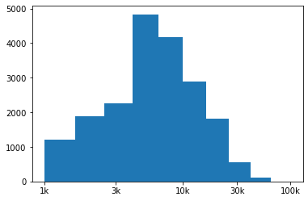

```python
bins = np.arange(3, loan.log_principal.max()+0.2, 0.2)
plt.hist(data=loan, x='log_principal', bins=bins)
plt.xscale('log')
ticks=np.array([1e3, 3e3, 1e4, 3e4, 1e5])
plt.xticks(log_trans(ticks), ['1k', '3k', '10k', '30k', '100k']);
```

> Most of the loan amount are between 5k to 10k, and the principal is normally distributed, plotted onn a logarithmic scale.

> Lastly, we will look into the borrower's employment status and occupation.

```python
employ_order = loan.EmploymentStatus.value_counts().index
occupation_order = loan.Occupation.value_counts().index
```

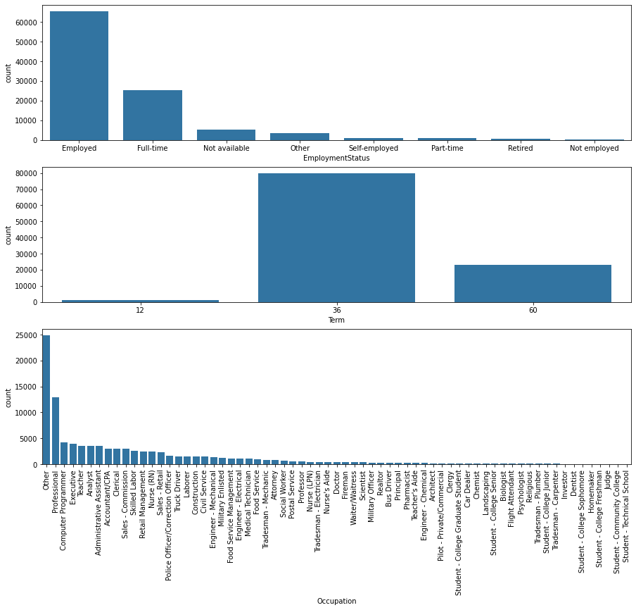

```python
fig, ax = plt.subplots(nrows=3, figsize=[15,12])
sb.countplot(data=loan, x='EmploymentStatus', color=default_color, order=employ_order, ax=ax[0]);
sb.countplot(data=loan, x='Term', color=default_color, ax=ax[1])
sb.countplot(data=loan, x='Occupation', color=default_color, order=occupation_order, ax=ax[2])
plt.xticks(rotation=90);
```

> From the bar chart of borrower's employment status, we notice that most of the borrowers are employed and full-time workers. Most of the occupations prove that the borrowers have a stable source of income, such as computer programmer and executives.

### Discuss the distribution(s) of your variable(s) of interest. Were there any unusual points? Did you need to perform any transformations?

> The principal variable took on a large range of values, so I looked at the data using a log transform. Under the transformation, the data looked normally distributed with one peak around 5k.

## Bivariate Exploration

```python
numeric_vars = ['ProsperPrincipalBorrowed', 'log_principal', 'EstimatedReturn', 'DebtToIncomeRatio', 'BorrowerAPR', 'BorrowerRate', 'CreditScoreRangeLower','StatedMonthlyIncome']
categoric_vars = ['LoanStatus', 'IncomeRange', 'ProsperScore', 'EmploymentStatus', 'Term']
```

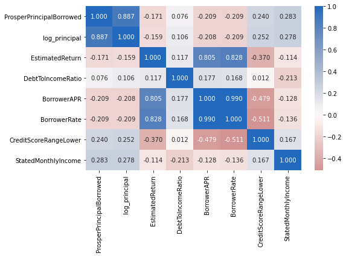

```python
# correlation plot
# notice there is a roughly negative correlation between borrower rate and credit score, principal borrowed and APR, monthly income and debt to income ratio.
plt.figure(figsize = [8, 5])
sb.heatmap(loan[numeric_vars].corr(), annot = True, fmt = '.3f',
           cmap = 'vlag_r', center = 0)
plt.show()
```

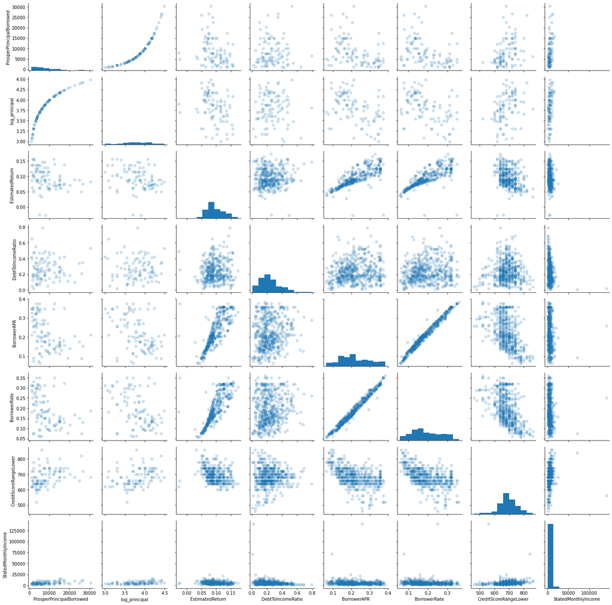

```python
# plot matrix: sample 1,000 borrowers data so that plots are clearer
np.random.seed(2021)
sample = np.random.choice(loan.shape[0], 500, replace=False)
df_sub = loan.iloc[sample, :]

g=sb.PairGrid(data=df_sub, vars=numeric_vars);
g=g.map_diag(plt.hist);
g.map_offdiag(plt.scatter, alpha=0.2);
```

As expected, borrowered APR, borrower interest, estimated return are highly correlated with one another. Sinceinterest rate is part of APR calculation, and higher APR usually yields higher return. In addition, borrower's rate and credit score are negatively correlated, which means the higher the credit score, the less the borrower's rate.

Suprisingly, there is a negative correlation between borrower's APR and loan original amount. The scatter plot also shows that these two variables are negatively correlated.

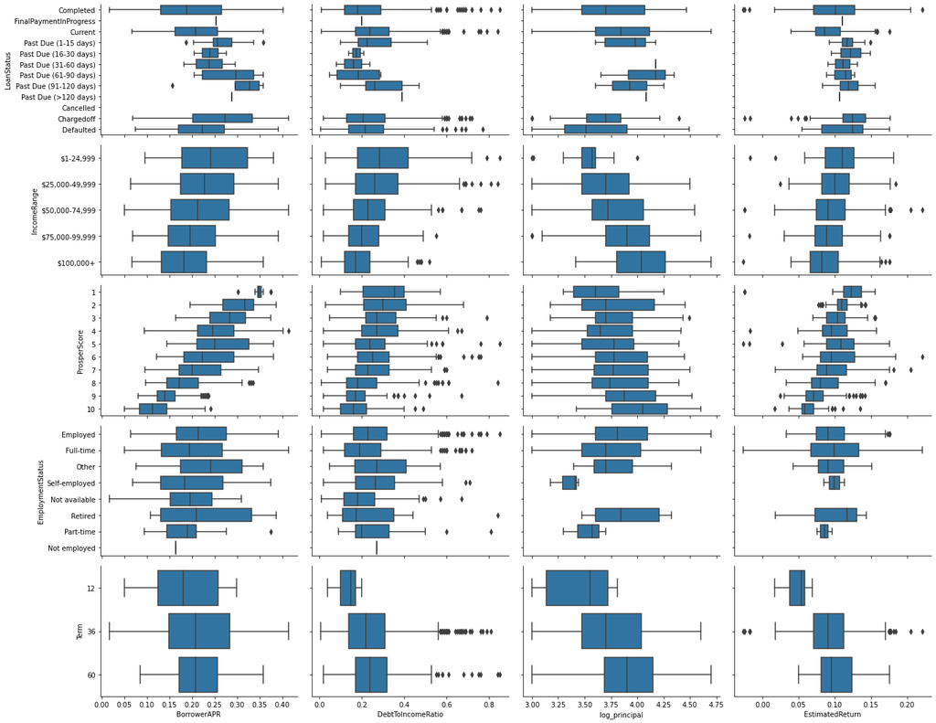

```python
# plot matrix of  numeric features against categorical features
samples = np.random.choice(loan.shape[0], 2000, replace=False)
df_sample = loan.iloc[samples,:]

default_color = sb.color_palette()[0]
plt.figure(figsize=[25,20]);
g=sb.PairGrid(data=df_sample, y_vars=categoric_vars, x_vars=['BorrowerAPR', 'DebtToIncomeRatio', 'log_principal', 'EstimatedReturn'],
             height=3, aspect=1.5);
g.map(sb.boxplot, color=default_color);
```

It appears that there are some positive and negative relationships between the categorical variables and the four numeric variables of interest.

Besides that, let's take a look at the factors impacts APR.

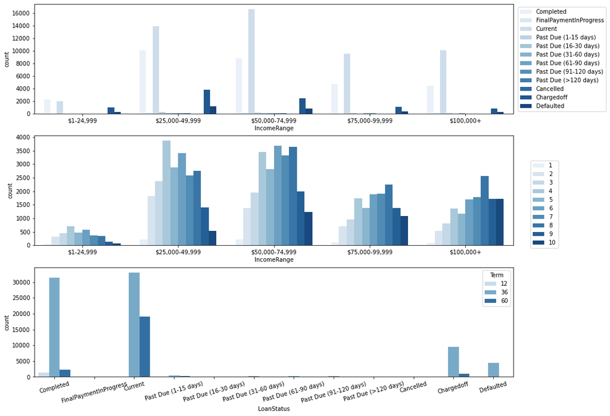

```python
fig, ax = plt.subplots(nrows=3, figsize=[15, 12])
#subplot 1: loan status vs income range
sb.countplot(data=loan, x ='IncomeRange', hue ='LoanStatus', palette = 'Blues', ax=ax[0])
ax[0].legend(loc='best', bbox_to_anchor=(0.7, 0.5, 0.5, 0.5))

#subplot 2: income range vs prosper score
sb.countplot(data=loan, x ='IncomeRange', hue ='ProsperScore', palette = 'Blues', ax=ax[1]);
ax[1].legend(loc='best', bbox_to_anchor=(0.6, 0.3, 0.5, 0.5))

#subplot 3: loan status vs term
sb.countplot(data=loan, x ='LoanStatus', hue ='Term', palette = 'Blues', ax=ax[2])
plt.xticks(rotation=15);
```

Interestingly, borrowers in the highest income range also appear to have certain defaulted and charged off happened. Charged off and defaulted has a bigger proportion within the income range of 25,000 to 49,999.

It seems like borrowers within higher income range have higher prosper score. Lastly, most of the loans are still under current progress, and also a large portion of loan marked as completed.

```python
loan.ProsperPrincipalBorrowed.describe()
```

```
count    19728.000000
mean      8515.522224
std       7388.174542
min       1000.000000
25%       3500.000000
50%       6000.000000
75%      11004.892500
max      67000.000000
Name: ProsperPrincipalBorrowed, dtype: float64
```

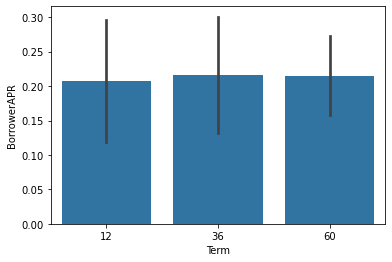

```python
sb.barplot(data=loan, x='Term', y='BorrowerAPR', color=default_color, ci='sd')
```

We can see that for shorter term loans, the lenders charges a variety of interest rate from the borrower as compared to longer term loans. Interestingly, the average APR on different terms of loans are around the same. To some extent, it shows that loan term doesn't have a big impact on the APR.

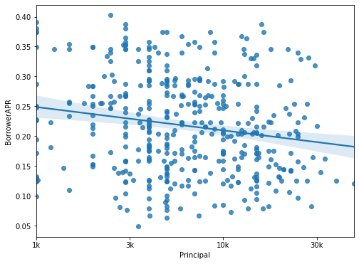

```python
plt.figure(figsize=[8,6])
sb.regplot(data=df_sample, x='log_principal', y='BorrowerAPR')
plt.xticks([3, 3.5, 4, 4.5], ['1k', '3k', '10k', '30k'])
plt.xlabel('Principal');
```

The scatterplot shows that as the principal amount increases, the borrower's APR descreases. The variables are negatively correlated with each other. Why is the APR even lower when the loan amount is bigger? Let's take a look at the relation between estimated return and principal.

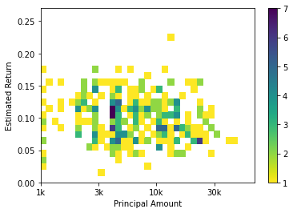

```python
bins_x=np.arange(loan.log_principal.min(), loan.log_principal.max()+0.05, 0.05)
bins_y=np.arange(0, loan.EstimatedReturn.max()+0.01, 0.01)
plt.hist2d(data=df_sample, x='log_principal', y='EstimatedReturn', bins=[bins_x, bins_y], cmin=0.02, cmap='viridis_r')
plt.colorbar()
plt.xticks([3, 3.5, 4, 4.5], ['1k', '3k', '10k', '30k'])
plt.xlabel('Principal Amount')
plt.ylabel('Estimated Return');
```

From the heatmap above, we noticed that there is a negative correlation between principal amount and estimated return. Larger amount of loans usually has lower rate of estimated return.

What about the relation between prosper score and estimated return? Does the high prosper score borrowers bring more money to the lender?

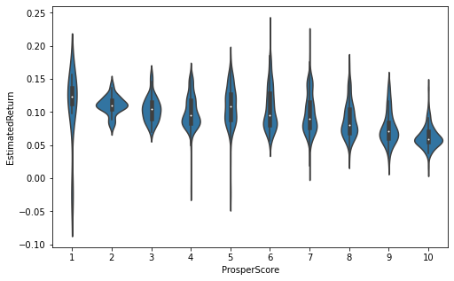

```python
plt.figure(figsize=[8,5])
sb.violinplot(data=df_sample, x='ProsperScore', y='EstimatedReturn', color=default_color);
```

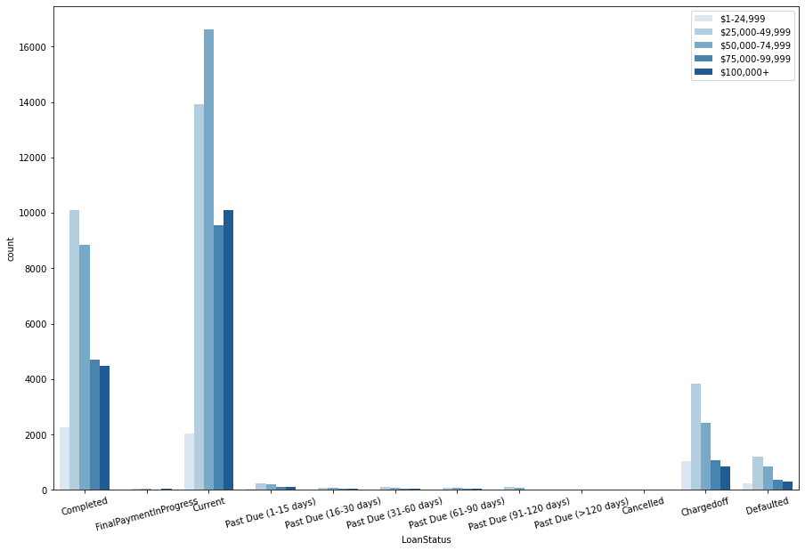

```python
plt.figure(figsize=[15,10])
sb.countplot(data=loan, x='LoanStatus', hue='IncomeRange', palette='Blues')
plt.xticks(rotation=15)
plt.legend(loc='best');
```

### Talk about some of the relationships you observed in this part of the investigation. How did the feature(s) of interest vary with other features in the dataset?

What affects the borrower's APR. First of all, borrower's APR has almost a linear relationship with borrower's interest rate, which is what we expected. Secondly, principal tend to have a negative impact on borrower's APR. In addition, on average, shorter term loan tend to have lower APR, but the APR doesn't vary that much. Lastly, borrowers with higher prosper score tend to have lower APR.

As far as borrower's income, it appears that the borrower's APR ranges vary widely. But on average, borrower's with higher income tend to have lower borrower's APR.

Besides that, we also notice that higher income usually lead to lower debt to income ratio, and borrower's with higher prosper score on average have higher loan amount.

## Multivariate Exploration

> Create plots of three or more variables to investigate your data even further. Make sure that your investigations are justified, and follow from your work in the previous sections.

```python
loan.IncomeRange.value_counts()
```

```
$25,000-49,999    29733
$50,000-74,999    29338
$100,000+         16065
$75,000-99,999    16011
$1-24,999          5692
Name: IncomeRange, dtype: int64
```

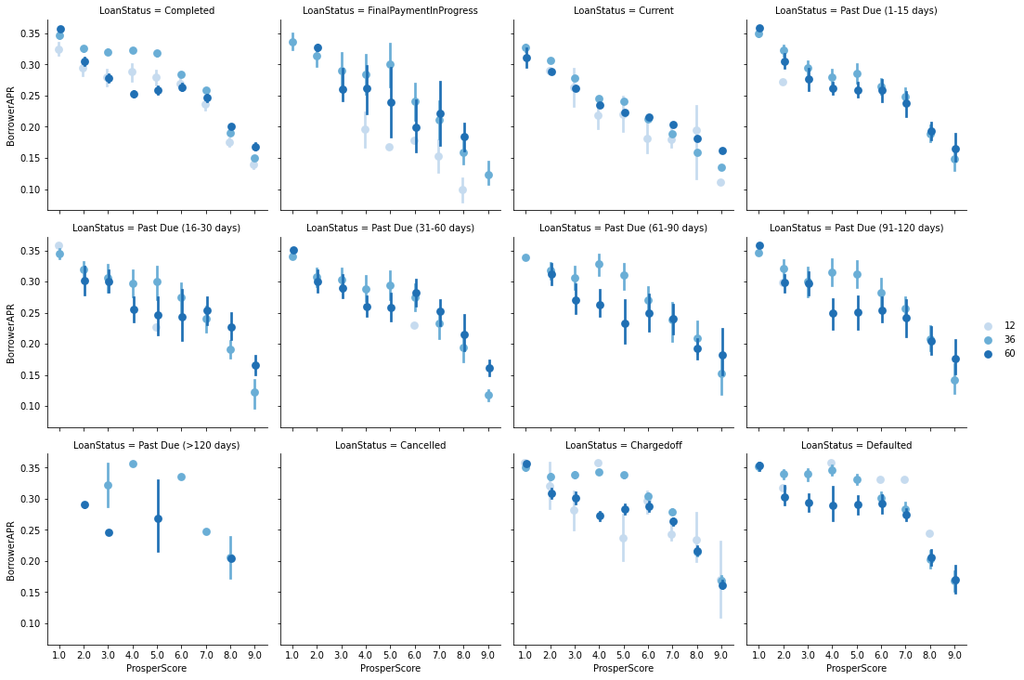

```python
g = sb.FacetGrid(data = loan, col = 'LoanStatus', col_wrap=4,
                height = 10.27/3, aspect = (14.7/4)/(10.27/3))
g.map(sb.pointplot, 'ProsperScore', 'BorrowerAPR', 'Term',
      linestyles = '', dodge=True, palette='Blues', order = [1.0, 2.0, 3.0, 4.0, 5.0, 6.0, 7.0, 8.0, 9.0])
g.add_legend()
plt.show()
```

The dodged pointplots above shows the influence of prosper score and APR on the status of loans. The larger error bars are due to there being fewer loans within certain loan status for certain loan Term.

From the point plot above, we notice that among different loan status, borrower's prosper score have a systematic negative impact on the average APR, except for prosper score between 4 and 6. Interestingly, the average borrower's APR is almost the same for borrowers whose prosper score is within 4 to 6. It also appears that, compared with propser score, the overall effect of loan Term on borrower's APR is smaller.

```python
#create a sub dataset to exclude the outliers of stated monthly income
loan_sub = loan_sub.loc[(loan_sub['StatedMonthlyIncome']>1000) & (loan_sub['StatedMonthlyIncome']<30000)]
```

```python
loan_sub.StatedMonthlyIncome.describe()
```

```
count    94706.000000
mean      5741.756955
std       3408.164571
min       1001.583333
25%       3450.250000
50%       5000.000000
75%       7083.333333
max      29833.333333
Name: StatedMonthlyIncome, dtype: float64
```

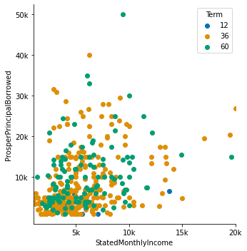

```python
# notice there are too many datapoints on the bottom left so we decide to transform the scale
g=sb.FacetGrid(data=df_sample, hue='Term', height=5, palette='colorblind')
g.map(plt.scatter, 'StatedMonthlyIncome', 'ProsperPrincipalBorrowed')
plt.xlim(1000, 20000)
xtickmarks=[5e3, 1e4, 15e3, 2e4]
plt.xticks(xtickmarks, ['5k', '10k', '15k', '20k'])
ytickmarks=[1e4, 2e4, 3e4, 4e4, 5e4]
plt.yticks(ytickmarks, ['10k', '20k', '30k', '40k', '50k'])
plt.legend([12, 36, 60], title='Term');
```

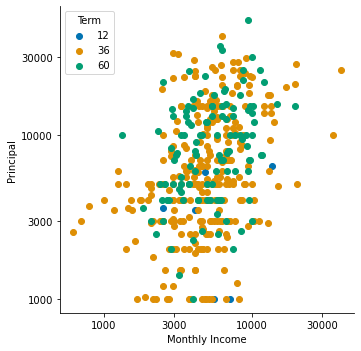

```python
g=sb.FacetGrid(data=df_sample, hue='Term', height=5,
              palette='colorblind')
g.map(plt.scatter, 'log_monthly_income', 'log_principal')
tickmarks=log_trans([1000, 3000, 10000, 30000])
plt.xticks(tickmarks, [1000, 3000, 10000, 30000])
plt.yticks(tickmarks, [1000, 3000, 10000, 30000])
plt.xlabel('Monthly Income')
plt.ylabel('Principal');
plt.legend([12, 36, 60], title='Term');
```

### Talk about some of the relationships you observed in this part of the investigation. Were there features that strengthened each other in terms of looking at your feature(s) of interest?

Among different loan status, borrower's prosper score have a systematic negative impact on the average APR. It also appears that, compared with propser score, the overall effect of loan Term on borrower's APR is smaller.

Lastly, we notice that there is a modest positive relationship between monthly income and principal borrowed. Adding the cateogrical vairable "Term", we can see the distributions of Term 60 and and Term 12 are relatively smaller than the distribution of Term 36.

### Were there any interesting or surprising interactions between features?

Although borrower's prosper score have a negative impact on the average APR, the APR doesn't change very much for borrowers whose prosper score is within 4 to 6. The relationship between prosper score and APR is more linear when we skip prosper score range 4 to 6.

> At the end of your report, make sure that you export the notebook as an html file from the `File > Download as... > HTML` menu. Make sure you keep track of where the exported file goes, so you can put it in the same folder as this notebook for project submission. Also, make sure you remove all of the quote-formatted guide notes like this one before you finish your report!